# TP Inicial de Estadística

2024-03-26

Leer la tabla

```r
data <- read.table("ENNyS_menorA2.txt", header = TRUE)
attach(data)
```

## Ejercicio 1

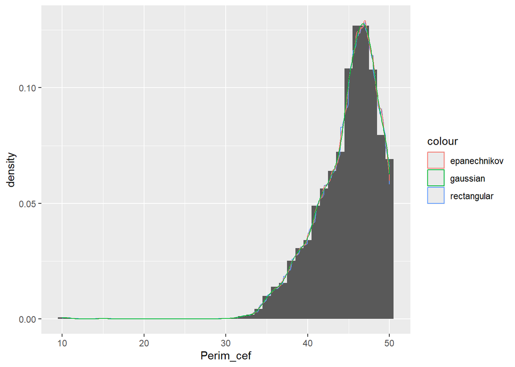

```r
library(ggplot2)

ggplot() +
  geom_histogram(aes(x = Perim_cef, y = after_stat(density)), binwidth = 1) +
  geom_density(aes(x = Perim_cef, y = after_stat(density), col = 'rectangular'), kernel = "rectangular") +
  geom_density(aes(x = Perim_cef, y = after_stat(density), col = 'epanechnikov'), kernel = "epanechnikov") +
  geom_density(aes(x = Perim_cef, y = after_stat(density), col = 'gaussian'), kernel = "gaussian")
```

Como se observa en el gráfico, las densidades estimadas casi no presentan diferencias, por lo que no parece ser una ventaja utilizar un núcleo por sobre otro.

## Ejercicio 2

#### a) Estimación usando el histograma

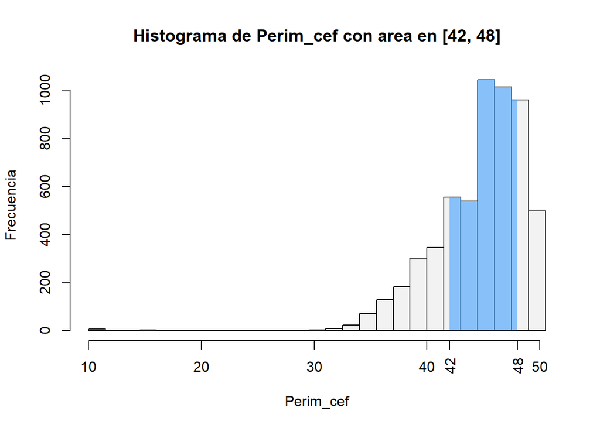

```r
data_range <- seq(floor(min(Perim_cef)), ceiling(max(Perim_cef)) + 1, by = 1.5)
hist_obj <- hist(Perim_cef, breaks = data_range, plot = FALSE)

# Ploteo el histograma
plot(hist_obj, col=gray(0.95), main="Histograma de Perim_cef con area en [42, 48]", xlab="Perim_cef", ylab="Frecuencia")

# Calculo los bin widths
bin_widths <- diff(hist_obj$breaks)

# Busco índices de los bins que tienen alguno de sus bordes entre 42 y 48
in_range_indices <- which(hist_obj$breaks[-length(hist_obj$breaks)] <= 48 & hist_obj$breaks[-1] >= 42)

# Resalto el área entre [42, 48]
for (i in in_range_indices) {
  left <- max(hist_obj$breaks[i], 42)
  right <- min(hist_obj$breaks[i + 1], 48)
  rect(left, 0, right, hist_obj$counts[i], col = rgb(0.12, 0.56, 1, 0.5), border = NA)
}
axis(1, at = c(42, 48), labels = c(42, 48), las = 2)
```

```r
# Calculo el área de los bins que están totalmente en rango (ambos bordes)
middle_bins <- hist_obj$density[in_range_indices[-c(1, length(in_range_indices))]]
middle_area <- sum(middle_bins * bin_widths[in_range_indices[-c(1, length(in_range_indices))]])

# Área parcial del primer bin en rango
first_bin_width = hist_obj$breaks[in_range_indices[1] + 1] - 42
first_area = first_bin_width * hist_obj$density[in_range_indices[1]]

# Área parcial del último bin en rango
last_bin_width = 48 - hist_obj$breaks[in_range_indices[length(in_range_indices)]]
last_area = last_bin_width * hist_obj$density[in_range_indices[length(in_range_indices)]]

# Sumo las áreas
total_area = first_area + middle_area + last_area

cat("Área total:", total_area, "\n")
```

```
## Área total: 0.5784003
```

#### b) Estimación usando la densidad con núcleo de Epanechnikov

```r
epanechnikov <- density(Perim_cef, kernel = "epanechnikov")
epanechnikov_cdf <- with(epanechnikov, splinefun(x, cumsum(y) / sum(y), method="monoH.FC"))
epanechnikov_cdf(48) - epanechnikov_cdf(42)
```

```
## [1] 0.5772641
```

No hay cuentas que justificar más allá del hecho de que la forma de estimar la probabilidad con el histograma es haciendo la suma de las áreas de las cajas del histograma que están comprendidas entre 42 y 48, y que $P_E\{42 < X < 48\} = P_E\{X < 48\} - P_E\{X < 42\}$, con $X$ siendo la variable aleatoria asociada al perímetro cefálico de un bebé y $P_E$ la función de distribución acumulada asociada a la densidad con núcleo de Epanechnikov.

## Ejercicio 3

Averiguamos las ventanas por defecto para cada núcleo (el parámetro $bw$). Según la documentación, se calcula con la función $\texttt{bw.nrd0(x)}$.

```r
print(bw.nrd0(Perim_cef))
```

```
## [1] 0.5841513
```

Con las ventanas por defecto se obtienen las siguientes densidades

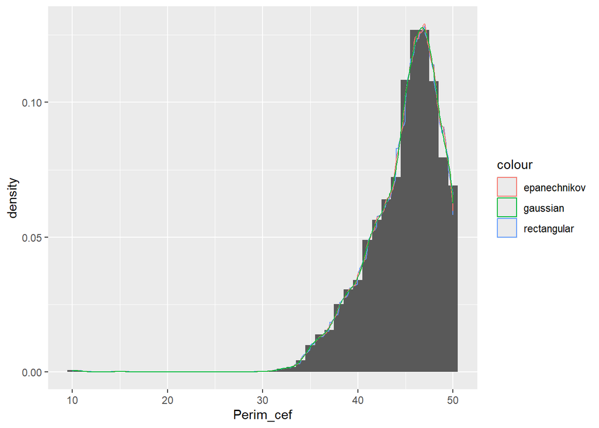

```r
library(ggplot2)

ggplot() +
  geom_histogram(aes(x = Perim_cef, y = after_stat(density)), binwidth = 1) +
  geom_density(aes(x = Perim_cef, y = after_stat(density), col = 'rectangular'), kernel = "rectangular") +
  geom_density(aes(x = Perim_cef, y = after_stat(density), col = 'epanechnikov'), kernel = "epanechnikov") +
  geom_density(aes(x = Perim_cef, y = after_stat(density), col = 'gaussian'), kernel = "gaussian")
```

Reduciendo la ventana a la mitad se obtienen las siguientes densidades (núcleo rectangular graficado en verde):

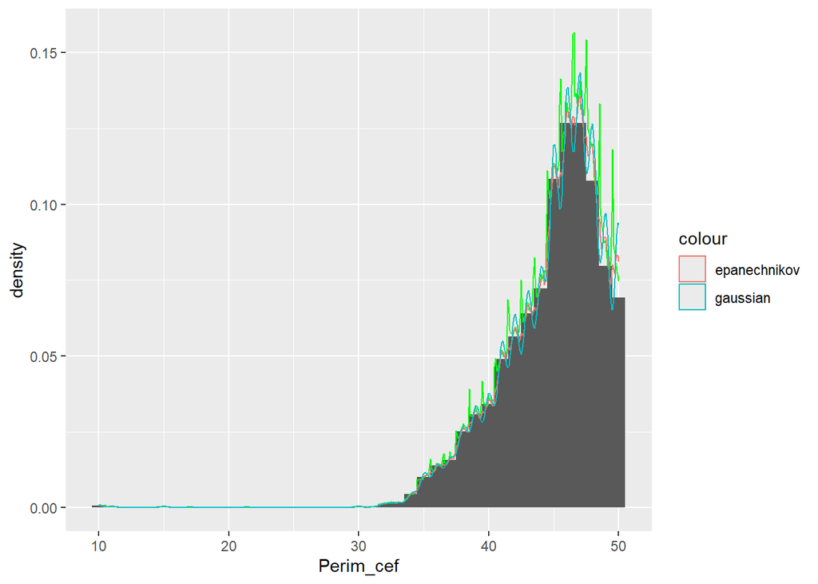

```r
ggplot() +
    geom_histogram(aes(x = Perim_cef, y = after_stat(density)), binwidth = 1) + geom_density(aes(x = Perim_cef, y = after_stat(density)), col = "green", kernel = "rectangular", adjust = 0.5) +
  geom_density(aes(x = Perim_cef, y = after_stat(density), col = 'epanechnikov'), kernel = "epanechnikov", adjust = 0.5) +
  geom_density(aes(x = Perim_cef, y = after_stat(density), col = 'gaussian'), kernel = "gaussian", adjust = 0.5)
```

Duplicando las ventanas se obtienen las siguientes densidades:

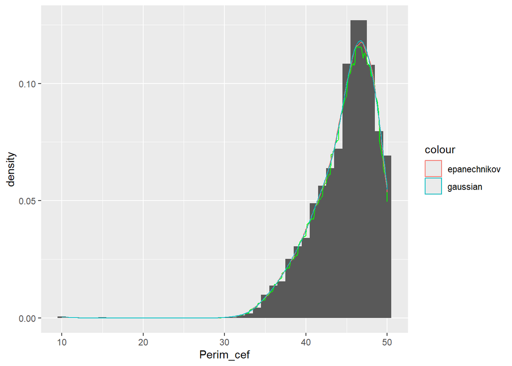

```r
ggplot() +
    geom_histogram(aes(x = Perim_cef, y = after_stat(density)), binwidth = 1) + geom_density(aes(x = Perim_cef, y = after_stat(density)), col = 'green', kernel = "rectangular", adjust = 2) +
  geom_density(aes(x = Perim_cef, y = after_stat(density), col = 'epanechnikov'), kernel = "epanechnikov", adjust = 2) +
  geom_density(aes(x = Perim_cef, y = after_stat(density), col = 'gaussian'), kernel = "gaussian", adjust = 2)
```

## Ejercicio 4

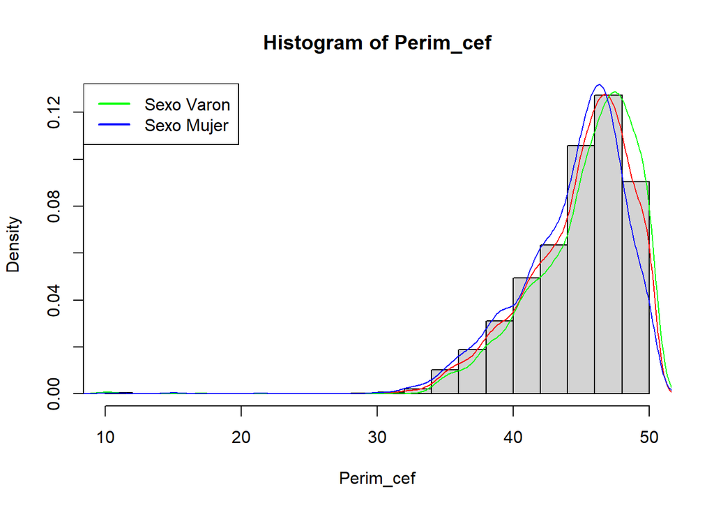

```r
hist(Perim_cef,breaks = 25,freq = FALSE)
lines(density(Perim_cef, kernel='gaussian'),col='red')
sexoVaron <- data[Sexo =='Varon',]
sexoMujer <- data[Sexo == 'Mujer',]
lines(density(sexoVaron$Perim_cef, kernel='gaussian'),col='green')
lines(density(sexoMujer$Perim_cef, kernel='gaussian'),col='blue')
legend("topleft", legend = c("Sexo Varon", "Sexo Mujer"), col = c("green", "blue"), lty = 1, lwd = 2)
```

Podemos observar que la curva de densidad de los varones está corrida hacia la derecha con respecto a la curva de la densidad de ambos sexos, lo que indica valores en general más grandes. A su vez, la curva de las mujeres está desplazada hacia la izquierda con respecto a la curva de densidad de ambos sexos. Podemos concluir que, en general, el perímetro cefálico de los varones es mayor que el de las mujeres.

## Ejercicio 5

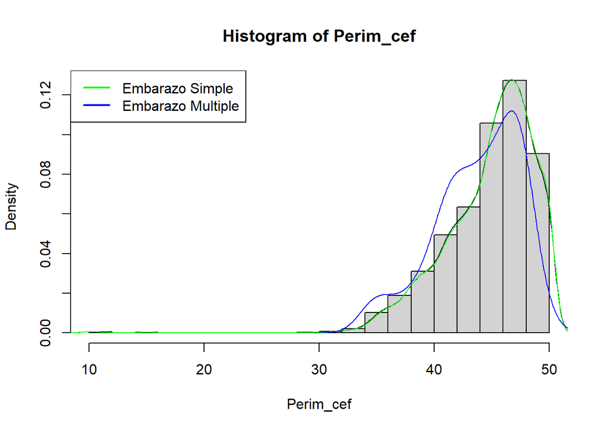

```r
hist(Perim_cef, breaks=25, freq=FALSE)
lines(density(Perim_cef, kernel='gaussian'))
embarazo_simple <- data[Tipo_embarazo=='Simple',]
embarazo_multiple <- data[Tipo_embarazo=='Multiple',]
lines(density(embarazo_simple$Perim_cef, kernel='gaussian'),col='green')
lines(density(embarazo_multiple$Perim_cef, kernel='gaussian'),col='blue')
legend("topleft", legend = c("Embarazo Simple", "Embarazo Multiple"), col = c("green", "blue"), lty = 1, lwd = 2)
```

Vemos que la distribución del perímetro cefálico de los bebés que provienen de un embarazo simple está más corrida hacia la derecha de los que provienen de un embarazo múltiple, y al mismo tiempo se encuentra más concentrada alrededor de los 47cm aproximadamente. Por lo tanto, podemos inferir que los primeros tienden a tener mayor perímetro cefálico, y menor variabilidad en dicha variable.

## Ejercicio 6

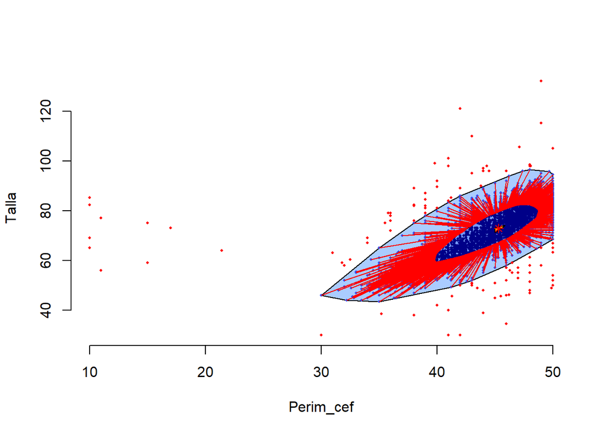

```r
library(aplpack)
bagplot(Perim_cef, Talla, xlab='Perim_cef', ylab='Talla')
```

Tenemos datos atípicos con valores muy bajos de “perímetro encefálico”, pero cuando esto sucede, la “talla” se encuentra en el rango esperable. Por otro lado, tenemos datos atípicos con valores muy altos y muy bajos de la “talla” pero, de la misma forma, cuando esto sucede, el “perímetro encefálico” se encuentra en el rango esperable. También tenemos datos con perímetro encefálico alto y talla baja, y también con perímetro encefálico mediano y talla alta y baja, que son atípicos en cuanto a la variable múltiple, pero no son atípicos en las variables por separado. Podemos concluir que no es común la presencia de individuos con ambas variables fuera de sus respectivos rangos esperados: en los casos en que una de las variables toma valores atípicos, la otra se encuentra dentro del rango esperado.

## Ejercicio 7

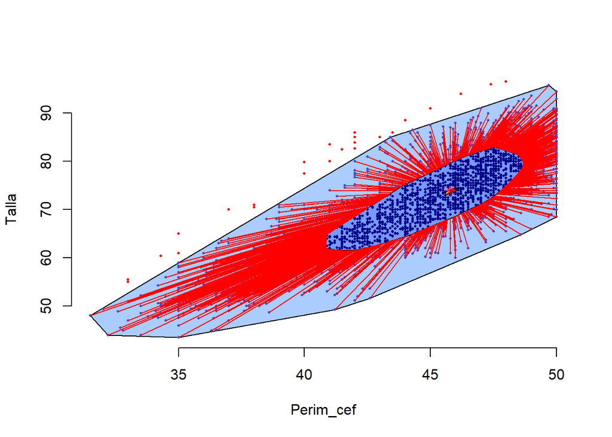

```r
outliers <- bagplot(Perim_cef, Talla, create.plot = FALSE, xlab='Perim_cef', ylab='Talla')$pxy.outlier

bagplot(Perim_cef[!Perim_cef %in% outliers[1:107] | !Talla %in% outliers[108:214]], Talla[!Perim_cef %in% outliers[1:107] | !Talla %in% outliers[108:214]], xlab='Perim_cef', ylab='Talla')
```

Se visualizan menos datos atípicos (fuera del polígono celeste). Viendo que los outliers forman una recta diagonal por encima del polígono celeste (loop) podemos inferir que existe una relación lineal entre las variables “Perímetro encefálico” y “Talla” de dichos valores.

## Ejercicio 8

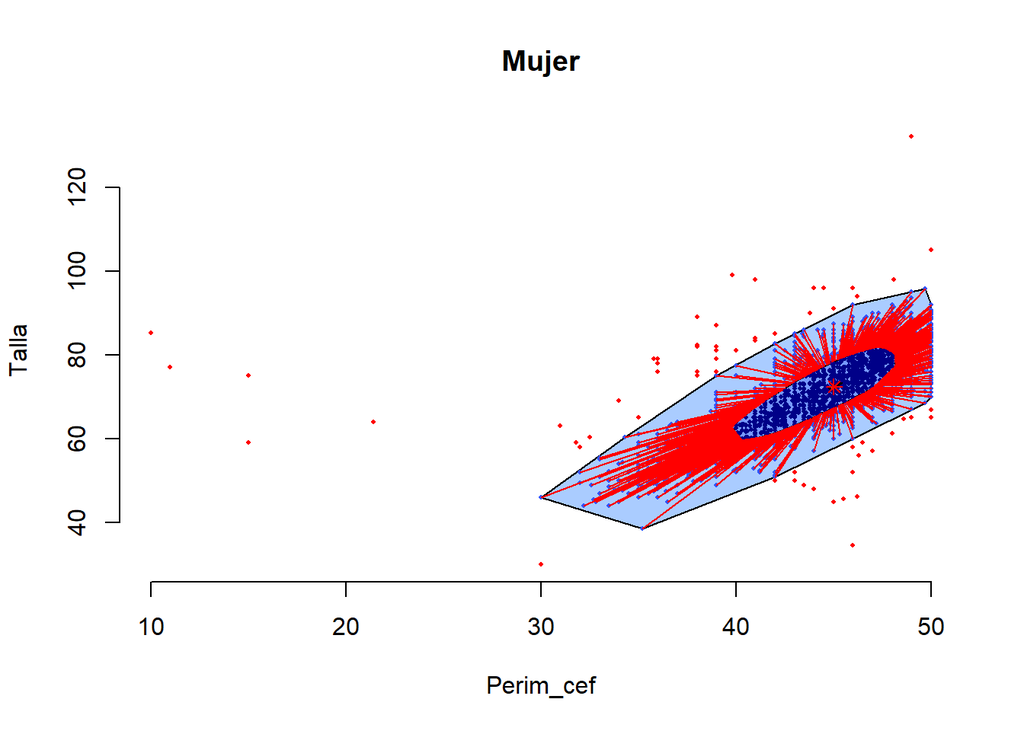

```r
data_mujer <- data[Sexo=='Mujer',]
data_varon <- data[Sexo=='Varon',]
bagplot(data_mujer$Perim_cef, data_mujer$Talla, main="Mujer", xlab='Perim_cef', ylab='Talla')
```

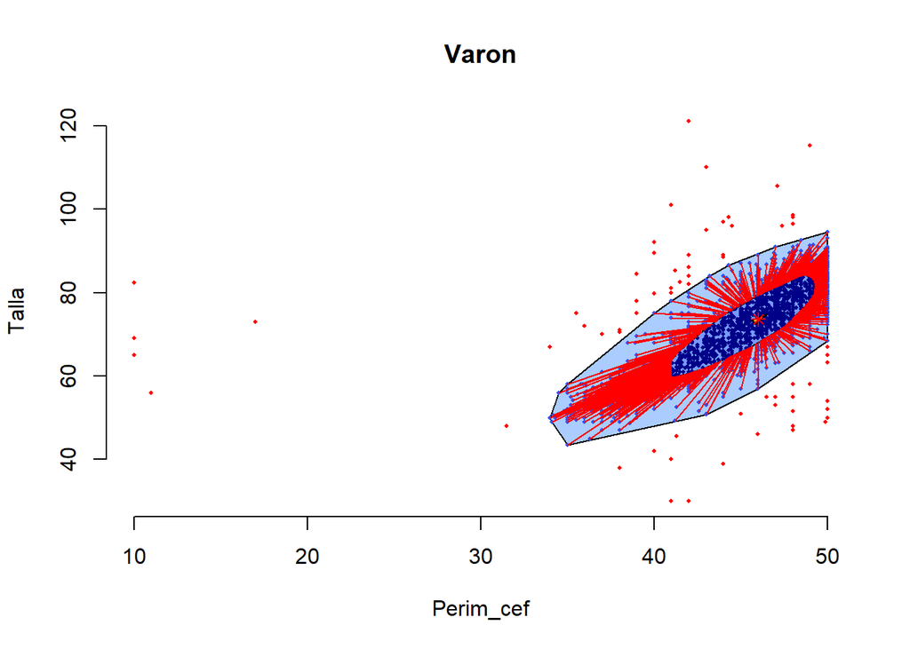

```r
bagplot(data_varon$Perim_cef, data_varon$Talla, main="Varon", xlab='Perim_cef', ylab='Talla')
```

Sí, se observan los mismos datos atípicos que en el item 6. Interpretamos que que la variable sexo no tiene incidencia sobre los outliers variable múltiple conformada por el perímetro encefálico y la talla. Por otro lado, sí vemos que el perímetro cefálico tiene valores esperados más bajos en mujeres que en varones, como en el ejercicio 4.